# Chapter 5: A shiny app

2017-06-21

## Introduction

## Introduction

- We've have relied on markdown for layout
  - **Trust me**: use `flexdashboard` if you can!
- When we create a full shiny app, we have to worry about layout
  - **Pro**: Finer control
  - **Con**: Bracket madness!

## Introduction: A shiny app

- `ui.R`
- `server.R`

## The `ui.R` file

- `ui.R`: user interface. Similar for most apps

```r
library("shiny")
fluidPage(
  titlePanel("Shiny happy people"), #title
  ## Sidebar with a slider input for no. of points
  sidebarLayout(
    sidebarPanel(
      sliderInput("n", "Number of points:", min = 1,
                                  max = 50, value = 30)
    ),
    ## Show a plot of the generated distribution
    mainPanel(plotOutput("scatter"))
  )
)
```

## Basic `ui.R` layout

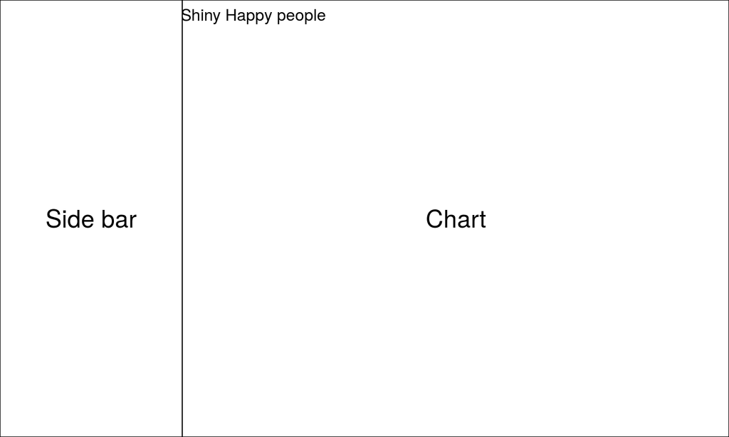

## The `server.R` file

- `server.R`: calculation logic
- Complement to `ui.R`

## The `server.R` file

```r
library("shiny")
# Function always has input & output
function(input, output) {
  # Expression that generates a plot.
  # A call to renderPlot indicates that:
  #  1) It is "reactive" and therefore should
  #   re-execute automatically when inputs change
  #  2) Its output type is a plot
  output$scatter = renderPlot({plot(rnorm(input$n))})
}
```

`output$scatter` links to the `plotOutput('scatter')`

## Chapter 5: Exercise 1

## Chapter 5: Exercise 1

```r
vignette("chapter5", package="jrShiny")
```

## Running the app (page 19)

## Running the app

  ```r
  library("shiny")
  runApp("my_app")
  ```

## Output objects (page 19)

- The above app is very similar to the flexdashboard.
- However there is one new addition, `Output`
- In the above code, `plotOutput` takes the plot function and creates an image.
  - `tableOutput` displays a table.
  - `textOutput` outputs some text.

## Output objects

| Output function | creates |
| --- | --- |
| `htmlOutput` | raw HTML |
| `imageOutput` | image |
| `plotOutput` | plot |
| `tableOutput` | table |
| `textOutput` | text |
| `uiOutput` | raw HTML |
| `verbatimTextOutput` | text |

## Layout (page 20)

- Shiny comes with tags.
  - The `em` tag is for italics

  ```r
  em("Some text")
  ```

- Most of the markdown tags we have encountered have a corresponding HTML tag.
- See table in the notes for more details

## The `fluidPage` function

- `fluidPage` adjusts the display to the dimensions of the browser's window.
- The easiest interface is to have is to have the sidebar layout – a sidebar panel and a main panel:

```r
fluidPage(
  titlePanel("Title panel"),# Title
  ## Sidebar style
  sidebarLayout(
    sidebarPanel("The sidebar"),
    mainPanel("Main panel")
  )
)
```

## `sidebarLayout`: swap sides

```r
sidebarLayout(position="right",
  sidebarPanel("The sidebar"),
  mainPanel("Main panel")
)
```

## `sidebarLayout`

To add content, just place it inside the `Panel` function.

```r
sidebarLayout(
  sidebarPanel("The sidebar", p("Choose an option")),
  mainPanel("Main panel")
)
```

## `sidebarLayout`

- `sidebarLayout` uses Shiny's lower-level grid layout functions.
  - Columns are defined by the `column`; rows by the `fluidRow` function.
- A page contains \(12\) columns.
  - Rows are created by the `fluidRow` function and include columns defined by the `column` function.
- Column widths: Bootstrap \(12\)-wide grid system

## Layout

```r
ui = fluidPage(
  titlePanel("I love movies"), #Title
  fluidRow( # Define a row
    column(4, # Two columns: width 4 & 8
    wellPanel(
      selectInput("movie_type", label = "Movie genre",
          c("Romance", "Action", "Animation"))
      )
    ),
  column(8, plotOutput("scatter"))
  )
)
```

## Other layouts

- **Tab Sets** Similar to the tabbed panel in `flexdashboard`
- **Navbar Pages** Similar to pages
- **Dashboards** Similar to the `flexdashboard`, but more powerful.

## Tab Sets

- We might use a `tabsetPanel` to have multiple tabs within a single main panel.
- Use `tabsetPanel` to create the structure.
- Add `tabPanel` content to add additional tabs within the panel

## Tab Sets

```r
mainPanel(
  tabsetPanel(type = "tabs",
              tabPanel("Plot", plotOutput("plot")),
              tabPanel("Summary", verbatimTextOutput("summary")),
              tabPanel("Table", tableOutput("table"))
  )
)
```

## Navbar

- `tabsetPanel` can only contain `tabPanel` elements.
- `tabsetPanel` can only be used in the main panel of a side bar layout.
- Consequently we could have a single sidebar common to all tabs.
- Overall structure is constant.

## Navbar

- With `navbarPage` we can have completely unique tabbed pages.
- Each page could have it's own layout
- One tab might have a side bar layout
- We could use tabsets within a navbar page

## Exercise

- Complete exercise Layouts

```r
vignette("chapter5",package = "jrShiny")
```

## Dashboards

- The `shinydashboard` package is an extension to `shiny`
- Set of utility functions for creation of dashboards

## Dashboards

- Made up of a `dashboardPage`
- Contains a header, sidebar and body
  - `dashboardHeader`
  - `dashboardSidebar`
  - `dashboardBody`

## Dashboard Header

- A dashboard header can be blank
- Contain the name of your app
- Can contain `dropdownMenu`

## Dashboard Sidebar

- Typically contains a `sideBarMenu` for navigation through the dashboard
- Can also contain other shiny inputs
- Could contain user information
- Search bars

## `sideBarMenu`

- A `sideBarMenu` consists of `menuItem`s
- `menuItem`s contain an id for a tabName
- Provides a link to the relevant tab within the dashboard body
- Can also include:
  - icons
  - badges
  - sub menus
  - link to an address

## Dashboard Body

- A dashboard body uses `tabItems` to link to the side bar menu
- `tabItems` contains individual `tabItem` elements
- `tabItem` is identified by its tabName id matching the `menuItem` tabName id
- An individual `tabItem` is then a panel, similar to the main panel from the sidebar layout

## Dashboard Body

- `tabItem` content is often organised using `box`es
- similar to the `column` 12 grid system, default width = 6
- but can be composed of standard shiny elements too

## Exercise

- The dashboard exercise gives a startpoint for a dashboard
- vignette("chapter5",package = "jrShiny")

## Interactive graphics with shiny

## Interactive graphics with shiny

Select points and regions as well as zooming in/out of images.

## Interactive graphics with shiny

As before, we create a `ui` component

```r
library("shiny")
## Basic layout. Two regions.
ui = basicPage(
  plotOutput("scatter", click = "plot_click"),
  verbatimTextOutput("info")
)
```

**Note** `click`

## Interactive graphics with shiny

- `click` captures where we clickThis will capture where we click on the plot.
- In `server.R` we get the variable `input$plot_click` ,

## Interactive graphics with shiny

```r
## Simulate data
x = signif(rnorm(10), 3); y = signif(rnorm(10), 3);
server = function(input, output) {
  output$scatter = renderPlot(plot(x, y))
  output$info = renderText({
    paste0("x=", input$plot_click$x, "\ny=", input$plot_click$y)
  })
}
```

## Exercise 3 and 4: Chapter 5

## The session argument

## session

- All of our shiny server functions so far have omitted the third optional argument `session`

```r
server = function(input,output,session){}
```

## session

- This argument is an R environment containing information and functionality relating to the current session
- There are lots of things you can do with this object
- Such as run a function when the page is bookmarked by a user
- Run code when a session is restored by the user

## session

- The things I most often find myself using it for are:
  - Sending messages to the clients browser
  - invalidating reactive expressions

## Invalidating reactive expressions

- Suppose you want to poll a database or data file for changes and update the graphics accordingly
- Or you want to cycle through samples within your data set at a regular time interval
- We could do this using `invalidateLater` and the `session` argument

## Invalidating reactive expressions

```r
server = function(input,output,session)
data = reactive({
  invalidateLater(1000)
  runif(10)
})
```

## Invalidating reactive expressions

- What this is doing is invalidating the reactive expression every 1000 milliseconds
- Causes the code within the reactive context to be re-evaluated
- In this case that generates a set of random numbers every second.

## `reactivePoll`

- If you were considering using the previous invalidation technique for pulling large amounts of data from a database and performing expensive rerendering it might be a bad idea
- `reactivePoll` might be better
- Used for polling data in a reactive way from a non-reactive source
- Use a cheap check function to see if the data has changed
- Only pull the updated data when it has

## Deployment

## Deployment: No shiny

[figure not shown]

## Deployment: Shiny

- Set up your own shiny [server](https://www.rstudio.com/products/shiny/shiny-server/)
  - Open-source version and a paid version.
- Host your app in the cloud with `shinyapps.io`
  - Free and paid [versions](http://shiny.rstudio.com/articles/shinyapps.html)

  ```r
  library("rsconnect")
  deployApp("name_of_app.Rmd")
  ```

## Deployment on Amazon

- You can try deploying an app on amazon if you like
- You can sign up for a free AWS account https://aws.amazon.com/
- You could either install shiny server yourself by following the instructions at rstudio
- Alternatively visit http://www.louisaslett.com/RStudio_AMI/ for a prepackaged version